# Final Project - Recession & Crimes

#### Data Wrangling

In order to find which quarters were in a recession, I will calculate the percentage change for GDP. Then I can filter out all of the positive values to get only recession entries.

```r
#calculate pecentage change of GDP and only display the values for a negative value to show recession years.

identify_recessions <- function(data) {
  # Ensure GDPC1 is numeric (if necessary, though assumed to be from prior exploration)
  data$GDPC1 <- as.numeric(data$GDPC1)

  # Calculate percentage change (pChange)
  data <- data %>%
    mutate(pChange = (GDPC1 - lag(GDPC1)) / lag(GDPC1) * 100)

  # Filter for recession periods (negative pChange)
  data_recessions <- data %>%
    filter(pChange < 0) %>%
    na.omit()

  return(data_recessions)
}

# Identify recessions using GDP data
GDP <- identify_recessions(GDP)

# Check for missing values in GDPC1
sum(is.na(GDP$GDPC1))  # Check if there are any NA values
```

```
[1] 0
```

```r
head(GDP)
```

| DATE | GDPC1 | pChange |
| --- | --- | --- |
| 1947-04-01 | 2176.892 | -0.2652243 |
| 1947-07-01 | 2172.432 | -0.2048792 |
| 1949-01-01 | 2260.807 | -1.3766138 |
| 1949-04-01 | 2253.128 | -0.3396575 |
| 1949-10-01 | 2257.352 | -0.8378053 |
| 1953-07-01 | 2902.785 | -0.5625160 |

Now I will finalize my GDP data. GDP is reported quarterly, but I need to make it annual so that it will match with the Crime table. To make it annual data, I am averaging the percentage change values for each year.

```r
#Crime data is only yearly. so need to get the GDP data into yearly. To do this, find the yearly average rate for GDP. Probably better to tell an actual recession because it'll give a closer estimate of consecutive periods and official recessions.

library(stringi)                                         #Required for stri_extract_last_regex

GDP <- GDP %>%                      #Extracts the year (last four digits) from the date
  mutate(Year=(stri_extract_last_regex(DATE, "\\d{4}")))

GDP<- GDP %>% group_by(Year ) %>%                       #Finds the average annual percent change in GDP
  summarize(GDP_Rate= mean(pChange))%>%ungroup()


head(GDP)
```

| Year | GDP_Rate |
| --- | --- |
| 1947 | -0.2350518 |
| 1949 | -0.8513589 |
| 1953 | -1.0381173 |
| 1954 | -0.4775705 |
| 1956 | -0.2388730 |
| 1957 | -0.6268393 |

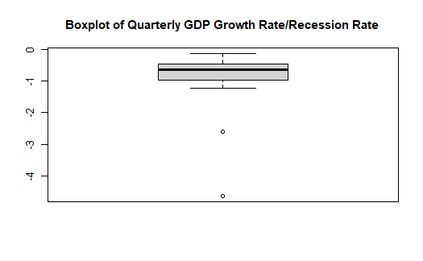

```r
# Plot boxplot if there are no missing values
if (!anyNA(GDP$GDP_Rate)) {
  boxplot(GDP$GDP_Rate, main = "Boxplot of Quarterly GDP Growth Rate/Recession Rate")
} else {
  cat("There are missing values in GDPC1 column. Please handle them before plotting.")
}
```

From box-plot we can see few outliers are there in the recession %, but those can be associated with major economic activities, thus keeping them as it is without truncating to some extreme end values

For CRIME dataset. column names are at 3rd row, only 20 rows are of our use, few NA columns are also there, so need to do pre processing of data before merging with GDP data on years

```r
col_names <- CRIME[3, ]       #reading 3rd row in crime data as columns name

# Remove the first three rows
CRIME <- CRIME[-c(1:3),]      #drop first 3 rows as null

# Assign the extracted column names to the data frame
names(CRIME) <- col_names
CRIME <- CRIME[1:20,]

CRIME <- CRIME[, colSums(is.na(CRIME)) != nrow(CRIME)]        #drop na columns

CRIME$Year <- gsub("20013", "2001", CRIME$Year)               #corret year typo

CRIME$Year <- gsub("20124", "2012", CRIME$Year)               #correct year typo

# Replace spaces with underscores in column names
colnames(CRIME) <- gsub("\n", "", colnames(CRIME))

head(CRIME)

print(colnames(CRIME))

CRIME$'Violent crime rate' <- as.numeric(CRIME$'Violent crime rate')     #converting chr datatype to numeric

# Check for outliers in crime rates
boxplot(CRIME$'Violent crime rate', main = "Boxplot of Violent Crime Rate")
```

[output not shown]